# Dissimilarity Analysis - Hogup Cave & Crescent Springs

2026-03-02

## Hogup Cave Occupational Phase Boundaries

```r
## STEP 1.1: Define Martin et al. (2017) occupational phase boundaries ----

phase_bounds <- list(
  I  = c(start = 9790, end = 6490),  # Strata 1–7
  II = c(start = 5840, end = 3330),  # Stratum 8
  III= c(start = 2870, end = 2760),  # Strata 9–10
  IV = c(start = 2610, end =  360)   # Strata 11–16
)
```

```r
## STEP 1.2: Map each cave pollen sample to a occupational phase ----

hogup_meta <- read.csv(here("..", "data", "raw", "hogup_pollen.csv"), check.names = TRUE)

# Function to map stratum to phase label
stratum_to_phase <- function(stratum) {
  if (stratum >= 1  & stratum <= 7)  return("I")
  if (stratum == 8)                  return("II")
  if (stratum == 9 | stratum == 10)  return("III")
  if (stratum >= 11 & stratum <= 16) return("IV")
  return(NA_character_)
}

hogup_meta$phase <- vapply(hogup_meta$stratum, stratum_to_phase, character(1))
hogup_meta$phase <- factor(hogup_meta$phase, levels = c("I", "II", "III", "IV"))

table(hogup_meta$stratum, hogup_meta$phase)
```

```
##
##      I II III IV
##   1  3  0   0  0
##   2  1  0   0  0
##   3  2  0   0  0
##   4  4  0   0  0
##   5  6  0   0  0
##   6  3  0   0  0
##   7  4  0   0  0
##   8  0  5   0  0
##   9  0  0   7  0
##   10 0  0   3  0
##   12 0  0   0  1
##   14 0  0   0  2
##   15 0  0   0  2
##   16 0  0   0  3
```

```r
## STEP 1.4: Choose a global time step for interpolation ----

time_step <- 100   # time step in years; adjust if needed
```

## Ordered Monte Carlo Age Assignments

```r
## STEP 2.1: Order samples within each phase by stratum ----

# Separate pollen data from metadata
meta_cols   <- c("sample", "stratum", "phase", "age")
cave_pollen <- hogup_meta[, !colnames(hogup_meta) %in% meta_cols, drop = FALSE]
hogup_meta  <- hogup_meta[,  meta_cols]

# Coerce all pollen columns to numeric
cave_pollen[] <- lapply(cave_pollen, function(x) suppressWarnings(as.numeric(as.character(x))))

# Set row names to sample ID to enforce alignment
rownames(cave_pollen) <- hogup_meta$sample
rownames(hogup_meta)  <- hogup_meta$sample

# Sort by stratum within phase (lower stratum number = older)
# Sample order within a particular stratum is shuffled
hogup_meta  <- hogup_meta[order(hogup_meta$phase, hogup_meta$stratum), ]
cave_pollen <- cave_pollen[rownames(hogup_meta), ]

# Count samples per phase
samples_per_phase <- table(hogup_meta$phase)
samples_per_phase
```

```
##
##   I  II III  IV
##  23   5  10   8
```

```r
## STEP 2.3: Function to generate one set of ordered ages for all samples ----

generate_ordered_ages <- function(meta, phase_bounds) {
  # meta: hogup_meta with columns sample, stratum, phase, age, is_residual
  # meta$age: exact cal BP date if known, NA otherwise
  # Returns: numeric vector of ages aligned with rows of 'meta'
  #
  # Anchored behaviour: samples with a finite age that are not residuals and
  # fall within their phase bounds act as fixed anchors. Anchors divide the
  # phase window into sub-intervals. Undated strata draw ordered-uniform ages
  # within their sub-interval. Undated samples in an anchor stratum are drawn
  # uniformly from the gap between the youngest assigned age in the immediately
  # older adjacent stratum and the oldest assigned age in the immediately
  # younger adjacent stratum (determined each realization after the sub-interval
  # draws, so the bounds reflect the actual sampled positions).

  ages <- numeric(nrow(meta))

  for (ph in names(phase_bounds)) {
    idx <- which(meta$phase == ph)
    if (length(idx) == 0) next

    ph_meta  <- meta[idx, ]
    ph_start <- phase_bounds[[ph]]["start"]  # older end (larger cal BP)
    ph_end   <- phase_bounds[[ph]]["end"]    # younger end (smaller cal BP)

    # Anchors: finite age, not residual, within this phase's bounds
    is_anchor <- is.finite(ph_meta$age) &
                 !ph_meta$is_residual   &
                 ph_meta$age <= ph_start &
                 ph_meta$age >= ph_end

    if (!any(is_anchor)) {
      # No anchors: original ordered-uniform behaviour
      n <- nrow(ph_meta)
      p <- sort(runif(n, 0, 1))
      a <- ph_start + p * (ph_end - ph_start)
      for (s in unique(ph_meta$stratum)) {
        sp <- which(ph_meta$stratum == s)
        a[sp] <- sample(a[sp], size = length(sp))
      }
      ages[idx] <- a
      next
    }

    # One representative age per anchor stratum
    anchor_strata <- sort(unique(ph_meta$stratum[is_anchor]))
    anchor_ages   <- sapply(anchor_strata, function(s)
      mean(ph_meta$age[ph_meta$stratum == s & is_anchor]))

    # Sub-interval boundaries (oldest to youngest in cal BP):
    #   [ph_start, anchor_ages[1], ..., ph_end]
    bounds_old <- c(ph_start, anchor_ages)
    bounds_yng <- c(anchor_ages, ph_end)

    a <- rep(NA_real_, nrow(ph_meta))

    # Pass 1: fix anchor samples at their exact known age
    for (i in seq_along(anchor_strata)) {
      sp <- which(ph_meta$stratum == anchor_strata[i] & is_anchor)
      a[sp] <- ph_meta$age[sp]
    }

    # Pass 2: draw ordered-uniform ages for undated non-anchor strata
    for (i in seq_along(bounds_old)) {
      sub_old <- bounds_old[i]
      sub_yng <- bounds_yng[i]

      sub_strata <- if (i == 1) {
        sort(unique(ph_meta$stratum[ph_meta$stratum < anchor_strata[1]]))
      } else if (i <= length(anchor_strata)) {
        sort(unique(ph_meta$stratum[ph_meta$stratum > anchor_strata[i - 1] &
                                    ph_meta$stratum < anchor_strata[i]]))
      } else {
        sort(unique(ph_meta$stratum[ph_meta$stratum > anchor_strata[length(anchor_strata)]]))
      }

      if (length(sub_strata) == 0) next

      # sub_idx is in stratum order because ph_meta is pre-sorted by stratum
      sub_idx <- which(ph_meta$stratum %in% sub_strata)
      n_sub   <- length(sub_idx)
      p_sub   <- sort(runif(n_sub, 0, 1))
      a[sub_idx] <- sub_old + p_sub * (sub_yng - sub_old)

      # Shuffle within each stratum (within-stratum order is unknowable)
      for (s in sub_strata) {
        sp <- which(ph_meta$stratum == s)
        if (length(sp) > 1) a[sp] <- sample(a[sp], size = length(sp))
      }
    }

    # Pass 3: assign undated samples in anchor strata
    # Bounds are derived from the actual assigned ages of the immediately
    # adjacent strata (determined in Pass 2), not from the sub-interval edges.
    for (i in seq_along(anchor_strata)) {
      anc_s      <- anchor_strata[i]
      undated_sp <- which(ph_meta$stratum == anc_s & !is_anchor)
      if (length(undated_sp) == 0) next

      # Immediately older adjacent stratum (largest stratum number < anc_s)
      older_candidates <- unique(ph_meta$stratum[ph_meta$stratum < anc_s])
      if (length(older_candidates) > 0) {
        adj_older_sp <- which(ph_meta$stratum == max(older_candidates))
        older_bound  <- min(a[adj_older_sp], na.rm = TRUE)
      } else {
        older_bound <- ph_start
      }

      # Immediately younger adjacent stratum (smallest stratum number > anc_s)
      younger_candidates <- unique(ph_meta$stratum[ph_meta$stratum > anc_s])
      if (length(younger_candidates) > 0) {
        adj_younger_sp <- which(ph_meta$stratum == min(younger_candidates))
        younger_bound  <- max(a[adj_younger_sp], na.rm = TRUE)
      } else {
        younger_bound <- ph_end
      }

      # Draw uniformly within [younger_bound, older_bound]
      a[undated_sp] <- runif(length(undated_sp), younger_bound, older_bound)
    }

    ages[idx] <- a
  }

  return(ages)
}
```

```r
## STEP 2.4: Handle the Stratum 9 residual pollen sample ----

hogup_meta$is_residual <- FALSE
hogup_meta$is_residual[hogup_meta$sample == 357] <- TRUE

residual_age_range <- c(4478, 4873)  # calibrated mid-Holocene range (cal BP)

# Variant 1: generate ages excluding the residual sample (Analysis A)
generate_ordered_ages_excl_resid <- function(meta, phase_bounds) {
  meta_no_resid <- meta[!meta$is_residual, ]
  ages_no_resid <- generate_ordered_ages(meta_no_resid, phase_bounds)
  ages <- rep(NA_real_, nrow(meta))
  ages[!meta$is_residual] <- ages_no_resid
  # residual sample intentionally has NA (excluded)
  return(ages)
}

# Variant 2: generate ages including residual as mid-Holocene (Analysis B)
generate_ordered_ages_incl_resid <- function(meta, phase_bounds, resid_range) {
  meta_no_resid <- meta[!meta$is_residual, ]
  ages_no_resid <- generate_ordered_ages(meta_no_resid, phase_bounds)
  ages <- rep(NA_real_, nrow(meta))
  ages[!meta$is_residual] <- ages_no_resid

  # assign residual sample its exact date if available, otherwise draw uniformly
  resid_idx <- which(meta$is_residual)
  if (length(resid_idx) == 1) {
    exact_age <- meta$age[resid_idx]
    ages[resid_idx] <- if (is.finite(exact_age)) exact_age else runif(1, resid_range[1], resid_range[2])
  }

  return(ages)
}
```

```r
## STEP 2.5: Generate many Monte Carlo realizations of ages ----

n_real <- 1000   # number of Monte Carlo realizations (adjust as needed, 200-1000)

# Storage lists
age_realizations_excl <- vector("list", n_real)
age_realizations_incl <- vector("list", n_real)

set.seed(123)   # reproducibility

for (k in 1:n_real) {
  age_realizations_excl[[k]] <- generate_ordered_ages_excl_resid(hogup_meta, phase_bounds)
  age_realizations_incl[[k]] <- generate_ordered_ages_incl_resid(hogup_meta, phase_bounds,
                                                                 resid_range = residual_age_range)
}
```

Age vectors now align with rows of `cave_pollen`. For realization `k`, cave ages excluding the residual are in `age_realizations_excl[[k]]` and cave ages including the residual as mid-Holocene are in `age_realizations_incl[[k]]`.

## Dissimilarity Analysis with Crescent Springs Core

```r
## STEP 3.0: Load Crescent Springs wetland pollen data ----

crescent_raw <- read.csv(here("..", "data", "raw", "crescent_pollen.csv"), check.names = TRUE)

wet_age <- crescent_raw$Age  # cal yr BP

meta_cols  <- c("Depth", "Age", "Pollen.Sum", "Terrestrial", "Lyco")
wet_pollen <- crescent_raw[, !colnames(crescent_raw) %in% meta_cols, drop = FALSE]
rownames(wet_pollen) <- crescent_raw$Depth
```

```r
## STEP 3.1: Prepare wetland core and harmonize taxa ----

# Convert to proportions
wet_prop  <- as.data.frame(wet_pollen / 100)
cave_prop <- as.data.frame(cave_pollen / 100)

# Harmonize taxa
common_taxa <- intersect(colnames(wet_prop), colnames(cave_prop))
wet_prop    <- wet_prop[,  common_taxa]
cave_prop   <- cave_prop[, common_taxa]
```

```r
## STEP 3.2: Define time grids ----

# Shared overlap grid: wetland–cave intersection (used for between-site SCD)
age_min <- max(min(wet_age), min(unlist(lapply(phase_bounds, `[[`, "end"))))
age_max <- min(max(wet_age), max(unlist(lapply(phase_bounds, `[[`, "start"))))
time_grid <- seq(age_min, age_max, by = time_step)

# Cave-only grid: full Phase I–IV extent (used for within-site cave RoC)
time_grid_cave <- seq(
  min(unlist(lapply(phase_bounds, `[[`, "end"))),    # youngest phase end
  max(unlist(lapply(phase_bounds, `[[`, "start"))),  # oldest phase start
  by = time_step
)
```

```r
## STEP 3.3: Helper to interpolate a pollen matrix to time_grid ----

interp_pollen <- function(age_vec, prop_mat, new_ages) {
  # age_vec: vector of sample ages (cal BP)
  # prop_mat: rows = samples, cols = taxa (proportions)
  # new_ages: desired ages (time_grid)

  ord <- order(age_vec)
  age_vec  <- age_vec[ord]
  prop_mat <- prop_mat[ord, , drop = FALSE]

  interp_mat <- sapply(
    1:ncol(prop_mat),
    function(j) approx(x = age_vec,
                       y = prop_mat[, j],
                       xout = new_ages,
                       rule = 2)$y
  )
  interp_df <- as.data.frame(interp_mat)
  colnames(interp_df) <- colnames(prop_mat)
  rownames(interp_df) <- as.character(new_ages)

  # renormalize rows to sum to 1 (guard against all-zero rows)
  rs <- rowSums(interp_df)
  rs[rs == 0] <- 1
  interp_df <- sweep(interp_df, 1, rs, "/")

  return(interp_df)
}
```

## Squared Chord Distance & Rate of Change

```r
## STEP 3.4: Functions for squared chord distance and RoC ----

compute_roc <- function(prop_df, ages) {
  # prop_df rows must correspond to 'ages' (time_grid)
  scd <- analogue::distance(
    x = prop_df[-nrow(prop_df), , drop = FALSE],
    y = prop_df[-1,           , drop = FALSE],
    method = "SQchord"
  )
  age_mid <- (ages[-nrow(prop_df)] + ages[-1]) / 2
  data.frame(age_mid = age_mid, SCD = diag(scd))
}

compute_between <- function(wet_df, cave_df, ages) {
  # wet_df, cave_df on same time_grid
  scd <- analogue::distance(
    x = wet_df,
    y = cave_df,
    method = "SQchord"
  )
  data.frame(age = ages, SCD = diag(scd))
}

# Wetland interpolation and RoC are identical across all realizations
wet_interp <- interp_pollen(wet_age, wet_prop, time_grid)
roc_wet    <- compute_roc(wet_interp, time_grid)

# Run Monte Carlo dissimilarity analyses
# Storage: one list per realization
roc_cave_A      <- vector("list", n_real)  # cave RoC on overlap grid (unused in Fig 2)
between_A       <- vector("list", n_real)
roc_cave_full_A <- vector("list", n_real)  # cave RoC on full Phase I–IV grid

roc_cave_B      <- vector("list", n_real)
between_B       <- vector("list", n_real)
roc_cave_full_B <- vector("list", n_real)

for (k in 1:n_real) {
  # Analysis A: exclude residual
  cave_age_A    <- age_realizations_excl[[k]]
  cave_interp_A <- interp_pollen(cave_age_A[!hogup_meta$is_residual],
                                 cave_prop[!hogup_meta$is_residual, ],
                                 time_grid)
  cave_interp_full_A <- interp_pollen(cave_age_A[!hogup_meta$is_residual],
                                      cave_prop[!hogup_meta$is_residual, ],
                                      time_grid_cave)

  roc_cave_A[[k]]      <- compute_roc(cave_interp_A,      time_grid)
  roc_cave_full_A[[k]] <- compute_roc(cave_interp_full_A, time_grid_cave)
  between_A[[k]]       <- compute_between(wet_interp, cave_interp_A, time_grid)

  # Analysis B: include residual as mid-Holocene
  cave_age_B    <- age_realizations_incl[[k]]
  cave_interp_B <- interp_pollen(cave_age_B, cave_prop, time_grid)
  cave_interp_full_B <- interp_pollen(cave_age_B, cave_prop, time_grid_cave)

  roc_cave_B[[k]]      <- compute_roc(cave_interp_B,      time_grid)
  roc_cave_full_B[[k]] <- compute_roc(cave_interp_full_B, time_grid_cave)
  between_B[[k]]       <- compute_between(wet_interp, cave_interp_B, time_grid)
}
```

## Summarize Monte Carlo Results

```r
## STEP 3.5: Summarize across realizations ----

# Helper: stack one SCD column from all realizations into a matrix
stack_metric <- function(list_of_df, colname = "SCD") {
  do.call(cbind, lapply(list_of_df, `[[`, colname))
}

# Helper: compute median and 95% CI envelope from a stacked matrix
summarise_metric <- function(mat, ages, age_col = "age_mid") {
  data.frame(
    setNames(list(ages), age_col),
    median = apply(mat, 1, median,   na.rm = TRUE),
    q025   = apply(mat, 1, quantile, probs = 0.025, na.rm = TRUE),
    q975   = apply(mat, 1, quantile, probs = 0.975, na.rm = TRUE)
  )
}

age_mid_vec      <- roc_cave_A[[1]]$age_mid       # overlap-grid midpoints (RoC)
age_mid_full_vec <- roc_cave_full_A[[1]]$age_mid  # cave-only midpoints (full RoC)
age_vec          <- between_A[[1]]$age            # shared time-grid ages (between)

# Wetland RoC is deterministic (no age uncertainty); reshape to match other summaries
roc_wet_summary <- data.frame(
  age_mid = roc_wet$age_mid,
  median  = roc_wet$SCD,
  q025    = roc_wet$SCD,
  q975    = roc_wet$SCD
)

# Analysis A
roc_cave_A_summary      <- summarise_metric(stack_metric(roc_cave_A),      age_mid_vec,      "age_mid")
roc_cave_full_A_summary <- summarise_metric(stack_metric(roc_cave_full_A), age_mid_full_vec, "age_mid")
between_A_summary       <- summarise_metric(stack_metric(between_A),       age_vec,          "age")

# Analysis B
roc_cave_B_summary      <- summarise_metric(stack_metric(roc_cave_B),      age_mid_vec,      "age_mid")
roc_cave_full_B_summary <- summarise_metric(stack_metric(roc_cave_full_B), age_mid_full_vec, "age_mid")
between_B_summary       <- summarise_metric(stack_metric(between_B),       age_vec,          "age")
```

## Results

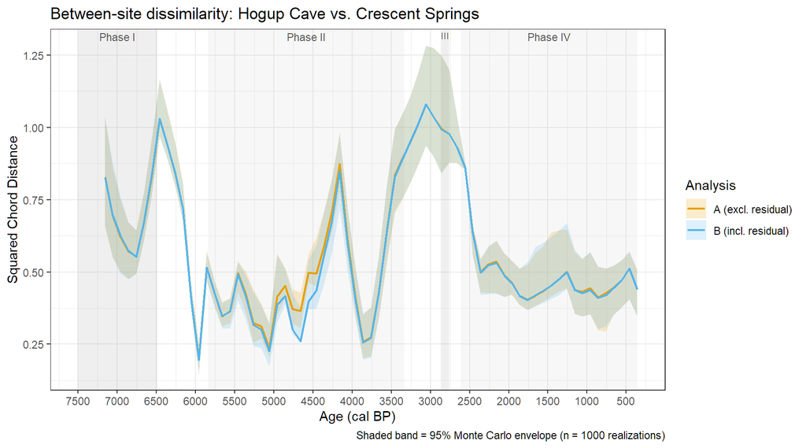

```r
library(ggplot2)

fig1_dat <- rbind(
  cbind(between_A_summary, analysis = "A (excl. residual)"),
  cbind(between_B_summary, analysis = "B (incl. residual)")
)
fig1_dat$analysis <- factor(fig1_dat$analysis,
                             levels = c("A (excl. residual)", "B (incl. residual)"))

fig1 <- ggplot(fig1_dat, aes(x = age, y = median,
                              colour = analysis, fill = analysis)) +
  # Occupation phase bands (Martin et al. 2017) — drawn first, beneath data
  # Phase I xmax capped at 7500 to match axis limit
  annotate("rect", xmin = 6490, xmax = 7500, ymin = -Inf, ymax = Inf, alpha = 0.12, fill = "grey50") +
  annotate("rect", xmin = 3330, xmax = 5840, ymin = -Inf, ymax = Inf, alpha = 0.06, fill = "grey50") +
  annotate("rect", xmin = 2760, xmax = 2870, ymin = -Inf, ymax = Inf, alpha = 0.12, fill = "grey50") +
  annotate("rect", xmin =  360, xmax = 2610, ymin = -Inf, ymax = Inf, alpha = 0.06, fill = "grey50") +
  annotate("text", x = (6490 + 7500) / 2, y = Inf, label = "Phase I",   vjust = 1.4, size = 3, colour = "grey35") +
  annotate("text", x = (3330 + 5840) / 2, y = Inf, label = "Phase II",  vjust = 1.4, size = 3, colour = "grey35") +
  annotate("text", x = (2760 + 2870) / 2, y = Inf, label = "III",       vjust = 1.4, size = 2.5, colour = "grey35") +
  annotate("text", x = ( 360 + 2610) / 2, y = Inf, label = "Phase IV",  vjust = 1.4, size = 3, colour = "grey35") +
  geom_ribbon(aes(ymin = q025, ymax = q975), alpha = 0.2, colour = NA) +
  geom_line(linewidth = 0.8) +
  scale_x_reverse(name = "Age (cal BP)",
                  limits = c(7500, NA),
                  breaks = seq(0, 7500, by = 500)) +
  scale_colour_manual(values = c("A (excl. residual)" = "#E69F00",
                                 "B (incl. residual)" = "#56B4E9"),
                      name = "Analysis") +
  scale_fill_manual(values = c("A (excl. residual)" = "#E69F00",
                                "B (incl. residual)" = "#56B4E9"),
                    name = "Analysis") +
  labs(y = "Squared Chord Distance",
       title = "Between-site dissimilarity: Hogup Cave vs. Crescent Springs",
       caption = "Shaded band = 95% Monte Carlo envelope (n = 1000 realizations)") +
  theme_bw(base_size = 11)

print(fig1)
```

**Figure 1** shows how dissimilar the pollen assemblages at Hogup Cave were from the contemporaneous wetland at Crescent Springs through time. High SCD indicates the two sites were recording very different vegetation — the cave and wetland assemblages were diverging. Low SCD indicates convergence, either because the wetland was influencing cave deposits or both sites were responding to the same regional conditions. Sustained high dissimilarity across a phase suggests Hogup Cave was accumulating pollen from a distinctly different local or regional source than the wetland (e.g., upland steppe taxa vs. wetland aquatics and halophytes). A drop in dissimilarity would suggest a convergence in vegetation — perhaps a wetter period pulling the cave assemblage toward wetland-type taxa — or a shift in human activity affecting what pollen entered the cave. The two analysis lines (A and B) allow assessment of whether the Stratum 9 residual sample meaningfully affects the pattern. If both lines track closely, the residual has little influence and the interpretation is robust. If they diverge, the timing and placement of that sample is driving the result and warrants closer attention.

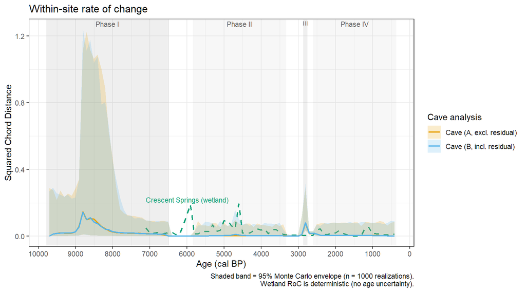

```r
fig2_cave <- rbind(
  cbind(roc_cave_full_A_summary, source = "Cave (A, excl. residual)"),
  cbind(roc_cave_full_B_summary, source = "Cave (B, incl. residual)")
)
fig2_cave$source <- factor(fig2_cave$source,
                            levels = c("Cave (A, excl. residual)",
                                       "Cave (B, incl. residual)"))

fig2_wet <- roc_wet_summary  # deterministic — single line, no envelope

fig2 <- ggplot() +
  # Occupation phase bands (Martin et al. 2017) — drawn first, beneath data
  annotate("rect", xmin = 6490, xmax = 9790, ymin = -Inf, ymax = Inf, alpha = 0.12, fill = "grey50") +
  annotate("rect", xmin = 3330, xmax = 5840, ymin = -Inf, ymax = Inf, alpha = 0.06, fill = "grey50") +
  annotate("rect", xmin = 2760, xmax = 2870, ymin = -Inf, ymax = Inf, alpha = 0.12, fill = "grey50") +
  annotate("rect", xmin =  360, xmax = 2610, ymin = -Inf, ymax = Inf, alpha = 0.06, fill = "grey50") +
  annotate("text", x = (6490 + 9790) / 2, y = Inf, label = "Phase I",   vjust = 1.4, size = 3, colour = "grey35") +
  annotate("text", x = (3330 + 5840) / 2, y = Inf, label = "Phase II",  vjust = 1.4, size = 3, colour = "grey35") +
  annotate("text", x = (2760 + 2870) / 2, y = Inf, label = "III",       vjust = 1.4, size = 2.5, colour = "grey35") +
  annotate("text", x = ( 360 + 2610) / 2, y = Inf, label = "Phase IV",  vjust = 1.4, size = 3, colour = "grey35") +
  geom_line(data = fig2_wet,
            aes(x = age_mid, y = median),
            colour = "#009E73", linetype = "dashed", linewidth = 0.8) +
  geom_ribbon(data = fig2_cave,
              aes(x = age_mid, ymin = q025, ymax = q975,
                  fill = source),
              alpha = 0.2) +
  geom_line(data = fig2_cave,
            aes(x = age_mid, y = median, colour = source),
            linewidth = 0.8) +
  scale_x_reverse(name = "Age (cal BP)",
                  breaks = seq(0, 10000, by = 1000)) +
  scale_colour_manual(values = c("Cave (A, excl. residual)" = "#E69F00",
                                 "Cave (B, incl. residual)" = "#56B4E9"),
                      name = "Cave analysis") +
  scale_fill_manual(values = c("Cave (A, excl. residual)" = "#E69F00",
                                "Cave (B, incl. residual)" = "#56B4E9"),
                    name = "Cave analysis") +
  annotate("text", x = max(roc_wet_summary$age_mid), y = max(roc_wet_summary$median),
           label = "Crescent Springs (wetland)", colour = "#009E73",
           hjust = 0, vjust = -0.3, size = 3) +
  labs(y = "Squared Chord Distance",
       title = "Within-site rate of change",
       caption = "Shaded band = 95% Monte Carlo envelope (n = 1000 realizations).\nWetland RoC is deterministic (no age uncertainty).") +
  theme_bw(base_size = 11)

print(fig2)
```

**Figure 2** shows how rapidly the pollen assemblage was changing internally at each site between consecutive time steps. High RoC (high SCD) indicates a period of ecological instability or rapid vegetation turnover, while low RoC indicates a stable, persistent vegetation community. The wetland line (dashed green) is deterministic — it carries no age uncertainty — so its peaks represent real, dateable vegetation transitions in the Crescent Springs basin. The cave envelopes (orange/blue) carry Monte Carlo age uncertainty: wider bands indicate time periods with fewer or more loosely constrained samples, where the biological signal is real but the exact timing is uncertain. Comparing the two sites, if a RoC peak appears at roughly the same time in both the cave and the wetland, it suggests a synchronous regional event such as a climatic shift. Asynchronous peaks may reflect site-specific processes — changes in human occupation intensity, local microenvironment, or taphonomy at the cave. As with Figure 1, comparing lines A and B reveals whether the Stratum 9 residual affects the timing or magnitude of rate-of-change events.

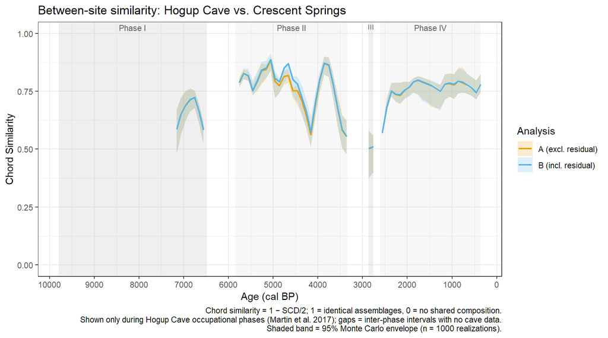

```r
# Helper: TRUE for ages falling within any occupational phase
in_occ_phase <- function(age) {
  Reduce(`|`, lapply(phase_bounds, function(b) age >= b["end"] & age <= b["start"]))
}

fig3_dat <- rbind(
  cbind(between_A_summary, analysis = "A (excl. residual)"),
  cbind(between_B_summary, analysis = "B (incl. residual)")
)
fig3_dat$analysis <- factor(fig3_dat$analysis,
                             levels = c("A (excl. residual)", "B (incl. residual)"))

# Convert SCD to chord similarity (1 - SCD/2); ranges 0 (dissimilar) to 1 (identical)
# Quantile order flips: low SCD = high similarity, so q025_SCD -> q975_sim
fig3_dat$sim_median <- 1 - fig3_dat$median / 2
fig3_dat$sim_q025   <- 1 - fig3_dat$q975   / 2
fig3_dat$sim_q975   <- 1 - fig3_dat$q025   / 2

# Mask inter-phase gaps — no cave data, so between-site comparison is uninformative
outside <- !in_occ_phase(fig3_dat$age)
fig3_dat$sim_median[outside] <- NA
fig3_dat$sim_q025[outside]   <- NA
fig3_dat$sim_q975[outside]   <- NA

fig3 <- ggplot(fig3_dat, aes(x = age, y = sim_median,
                              colour = analysis, fill = analysis)) +
  # Occupation phase bands (Martin et al. 2017) — drawn first, beneath data
  annotate("rect", xmin = 6490, xmax = 9790, ymin = -Inf, ymax = Inf, alpha = 0.12, fill = "grey50") +
  annotate("rect", xmin = 3330, xmax = 5840, ymin = -Inf, ymax = Inf, alpha = 0.06, fill = "grey50") +
  annotate("rect", xmin = 2760, xmax = 2870, ymin = -Inf, ymax = Inf, alpha = 0.12, fill = "grey50") +
  annotate("rect", xmin =  360, xmax = 2610, ymin = -Inf, ymax = Inf, alpha = 0.06, fill = "grey50") +
  annotate("text", x = (6490 + 9790) / 2, y = Inf, label = "Phase I",   vjust = 1.4, size = 3, colour = "grey35") +
  annotate("text", x = (3330 + 5840) / 2, y = Inf, label = "Phase II",  vjust = 1.4, size = 3, colour = "grey35") +
  annotate("text", x = (2760 + 2870) / 2, y = Inf, label = "III",       vjust = 1.4, size = 2.5, colour = "grey35") +
  annotate("text", x = ( 360 + 2610) / 2, y = Inf, label = "Phase IV",  vjust = 1.4, size = 3, colour = "grey35") +
  geom_ribbon(aes(ymin = sim_q025, ymax = sim_q975), alpha = 0.2, colour = NA) +
  geom_line(linewidth = 0.8) +
  scale_x_reverse(name = "Age (cal BP)",
                  breaks = seq(0, 10000, by = 1000)) +
  scale_y_continuous(name = "Chord Similarity",
                     limits = c(0, 1)) +
  scale_colour_manual(values = c("A (excl. residual)" = "#E69F00",
                                 "B (incl. residual)" = "#56B4E9"),
                      name = "Analysis") +
  scale_fill_manual(values = c("A (excl. residual)" = "#E69F00",
                                "B (incl. residual)" = "#56B4E9"),
                    name = "Analysis") +
  labs(title = "Between-site similarity: Hogup Cave vs. Crescent Springs",
       caption = "Chord similarity = 1 − SCD/2; 1 = identical assemblages, 0 = no shared composition.\nShown only during Hogup Cave occupational phases (Martin et al. 2017); gaps = inter-phase intervals with no cave data.\nShaded band = 95% Monte Carlo envelope (n = 1000 realizations).") +
  theme_bw(base_size = 11)

print(fig3)
```

### Summary tables

```r
knitr::kable(between_A_summary, digits = 4,
             col.names = c("Age (cal BP)", "Median SCD", "2.5%", "97.5%"),
             caption = "Between-site SCD — Analysis A (residual excluded)")
```

Between-site SCD — Analysis A (residual excluded)

| Age (cal BP) | Median SCD | 2.5% | 97.5% |
| --- | --- | --- | --- |
| 360 | 0.4394 | 0.3461 | 0.5074 |
| 460 | 0.5122 | 0.4055 | 0.5706 |
| 560 | 0.4699 | 0.3765 | 0.5391 |
| 660 | 0.4453 | 0.3521 | 0.5213 |
| 760 | 0.4281 | 0.2943 | 0.5114 |
| 860 | 0.4116 | 0.2999 | 0.5183 |
| 960 | 0.4446 | 0.3521 | 0.5679 |
| 1060 | 0.4320 | 0.3455 | 0.5449 |
| 1160 | 0.4383 | 0.3550 | 0.5696 |
| 1260 | 0.5001 | 0.4435 | 0.6479 |
| 1360 | 0.4744 | 0.4314 | 0.6449 |
| 1460 | 0.4528 | 0.4150 | 0.6357 |
| 1560 | 0.4337 | 0.3975 | 0.5884 |
| 1660 | 0.4191 | 0.3824 | 0.5668 |
| 1760 | 0.4044 | 0.3680 | 0.5247 |
| 1860 | 0.4170 | 0.3853 | 0.5117 |
| 1960 | 0.4632 | 0.4219 | 0.5395 |
| 2060 | 0.4897 | 0.4144 | 0.5641 |
| 2160 | 0.5358 | 0.4259 | 0.6089 |
| 2260 | 0.5260 | 0.4258 | 0.5869 |
| 2360 | 0.4994 | 0.4306 | 0.5443 |
| 2460 | 0.6404 | 0.5587 | 0.6619 |
| 2560 | 0.8602 | 0.8529 | 0.8769 |
| 2660 | 0.9297 | 0.8763 | 1.0320 |
| 2760 | 0.9774 | 0.8790 | 1.2005 |
| 2860 | 0.9965 | 0.8415 | 1.2491 |
| 2960 | 1.0360 | 0.9007 | 1.2756 |
| 3060 | 1.0803 | 0.9362 | 1.2827 |
| 3160 | 1.0118 | 0.8685 | 1.1880 |
| 3260 | 0.9485 | 0.8060 | 1.1060 |
| 3360 | 0.8908 | 0.7496 | 1.0450 |
| 3460 | 0.8341 | 0.7030 | 0.9935 |
| 3560 | 0.6437 | 0.5288 | 0.8006 |
| 3660 | 0.4319 | 0.3431 | 0.5530 |
| 3760 | 0.2755 | 0.2092 | 0.3786 |
| 3860 | 0.2587 | 0.2027 | 0.3528 |
| 3960 | 0.4093 | 0.3498 | 0.5143 |
| 4060 | 0.6113 | 0.5463 | 0.7204 |
| 4160 | 0.8743 | 0.7809 | 0.9821 |
| 4260 | 0.7078 | 0.6379 | 0.8212 |
| 4360 | 0.5863 | 0.5354 | 0.7071 |
| 4460 | 0.4949 | 0.4516 | 0.6194 |
| 4560 | 0.4981 | 0.4623 | 0.5607 |
| 4660 | 0.3645 | 0.3075 | 0.4287 |
| 4760 | 0.3711 | 0.3199 | 0.4392 |
| 4860 | 0.4518 | 0.4090 | 0.5145 |
| 4960 | 0.4155 | 0.3486 | 0.5632 |
| 5060 | 0.2368 | 0.2047 | 0.3246 |
| 5160 | 0.3114 | 0.2701 | 0.3901 |
| 5260 | 0.3227 | 0.2562 | 0.4392 |
| 5360 | 0.4213 | 0.3584 | 0.5003 |
| 5460 | 0.4966 | 0.4317 | 0.5367 |
| 5560 | 0.3648 | 0.3230 | 0.4100 |
| 5660 | 0.3457 | 0.3128 | 0.3951 |
| 5760 | 0.4242 | 0.3810 | 0.4708 |
| 5860 | 0.5148 | 0.4717 | 0.5738 |
| 5960 | 0.1968 | 0.1492 | 0.2507 |
| 6060 | 0.4136 | 0.3773 | 0.4678 |
| 6160 | 0.7189 | 0.6757 | 0.8080 |
| 6260 | 0.8370 | 0.7938 | 0.9461 |
| 6360 | 0.9365 | 0.8893 | 1.0596 |
| 6460 | 1.0287 | 0.9669 | 1.1647 |
| 6560 | 0.8291 | 0.7654 | 0.9594 |
| 6660 | 0.6695 | 0.6081 | 0.7711 |
| 6760 | 0.5545 | 0.4950 | 0.6441 |
| 6860 | 0.5699 | 0.4762 | 0.6712 |
| 6960 | 0.6206 | 0.5022 | 0.7487 |
| 7060 | 0.6957 | 0.5518 | 0.8636 |
| 7160 | 0.8288 | 0.6553 | 1.0314 |

```r
knitr::kable(between_B_summary, digits = 4,
             col.names = c("Age (cal BP)", "Median SCD", "2.5%", "97.5%"),
             caption = "Between-site SCD — Analysis B (residual as mid-Holocene)")
```

Between-site SCD — Analysis B (residual as mid-Holocene)

| Age (cal BP) | Median SCD | 2.5% | 97.5% |
| --- | --- | --- | --- |
| 360 | 0.4394 | 0.3461 | 0.5074 |
| 460 | 0.5122 | 0.4055 | 0.5706 |
| 560 | 0.4699 | 0.3758 | 0.5391 |
| 660 | 0.4450 | 0.3486 | 0.5213 |
| 760 | 0.4201 | 0.3113 | 0.5114 |
| 860 | 0.4108 | 0.3028 | 0.5183 |
| 960 | 0.4386 | 0.3535 | 0.5679 |
| 1060 | 0.4267 | 0.3455 | 0.5468 |
| 1160 | 0.4379 | 0.3549 | 0.5764 |
| 1260 | 0.4994 | 0.4420 | 0.6686 |
| 1360 | 0.4755 | 0.4203 | 0.6428 |
| 1460 | 0.4523 | 0.4052 | 0.6198 |
| 1560 | 0.4347 | 0.3930 | 0.6016 |
| 1660 | 0.4198 | 0.3814 | 0.5857 |
| 1760 | 0.4030 | 0.3681 | 0.5343 |
| 1860 | 0.4165 | 0.3858 | 0.5122 |
| 1960 | 0.4626 | 0.4218 | 0.5400 |
| 2060 | 0.4882 | 0.4143 | 0.5643 |
| 2160 | 0.5317 | 0.4246 | 0.6072 |
| 2260 | 0.5231 | 0.4238 | 0.5889 |
| 2360 | 0.4983 | 0.4204 | 0.5439 |
| 2460 | 0.6359 | 0.5586 | 0.6625 |
| 2560 | 0.8602 | 0.8528 | 0.8769 |
| 2660 | 0.9297 | 0.8762 | 1.0319 |
| 2760 | 0.9775 | 0.8789 | 1.1999 |
| 2860 | 0.9930 | 0.8419 | 1.2477 |
| 2960 | 1.0366 | 0.9001 | 1.2737 |
| 3060 | 1.0800 | 0.9365 | 1.2839 |
| 3160 | 1.0115 | 0.8691 | 1.1875 |
| 3260 | 0.9494 | 0.8077 | 1.1050 |
| 3360 | 0.8888 | 0.7548 | 1.0449 |
| 3460 | 0.8293 | 0.7110 | 0.9913 |
| 3560 | 0.6391 | 0.5423 | 0.8011 |
| 3660 | 0.4294 | 0.3389 | 0.5566 |
| 3760 | 0.2723 | 0.2038 | 0.3761 |
| 3860 | 0.2557 | 0.1980 | 0.3565 |
| 3960 | 0.4014 | 0.3343 | 0.5100 |
| 4060 | 0.5963 | 0.5034 | 0.7195 |
| 4160 | 0.8498 | 0.7191 | 0.9769 |
| 4260 | 0.6738 | 0.5636 | 0.8167 |
| 4360 | 0.5550 | 0.4553 | 0.7047 |
| 4460 | 0.4370 | 0.3735 | 0.5926 |
| 4560 | 0.3975 | 0.3700 | 0.5389 |
| 4660 | 0.2601 | 0.2531 | 0.3761 |
| 4760 | 0.2999 | 0.2859 | 0.4236 |
| 4860 | 0.4163 | 0.3882 | 0.5110 |
| 4960 | 0.3866 | 0.3251 | 0.5582 |
| 5060 | 0.2260 | 0.1727 | 0.3201 |
| 5160 | 0.3006 | 0.2363 | 0.3844 |
| 5260 | 0.3160 | 0.2442 | 0.4291 |
| 5360 | 0.4143 | 0.3348 | 0.4895 |
| 5460 | 0.4928 | 0.4011 | 0.5350 |
| 5560 | 0.3641 | 0.3044 | 0.4077 |
| 5660 | 0.3468 | 0.3062 | 0.3924 |
| 5760 | 0.4246 | 0.3764 | 0.4619 |
| 5860 | 0.5151 | 0.4662 | 0.5668 |
| 5960 | 0.1951 | 0.1479 | 0.2565 |
| 6060 | 0.4139 | 0.3751 | 0.4637 |
| 6160 | 0.7191 | 0.6737 | 0.8031 |
| 6260 | 0.8390 | 0.7924 | 0.9396 |
| 6360 | 0.9372 | 0.8879 | 1.0538 |
| 6460 | 1.0300 | 0.9668 | 1.1652 |
| 6560 | 0.8357 | 0.7656 | 0.9615 |
| 6660 | 0.6705 | 0.6069 | 0.7738 |
| 6760 | 0.5530 | 0.4926 | 0.6457 |
| 6860 | 0.5742 | 0.4749 | 0.6727 |
| 6960 | 0.6247 | 0.4942 | 0.7587 |
| 7060 | 0.6984 | 0.5532 | 0.8794 |
| 7160 | 0.8272 | 0.6567 | 1.0368 |

```r
knitr::kable(roc_cave_A_summary, digits = 4,
             col.names = c("Age midpoint (cal BP)", "Median SCD", "2.5%", "97.5%"),
             caption = "Cave RoC — Analysis A")
```

Cave RoC — Analysis A

| Age midpoint (cal BP) | Median SCD | 2.5% | 97.5% |
| --- | --- | --- | --- |
| 410 | 0.0000 | 0.0000 | 0.0860 |
| 510 | 0.0000 | 0.0000 | 0.0804 |
| 610 | 0.0029 | 0.0000 | 0.0645 |
| 710 | 0.0034 | 0.0000 | 0.0869 |
| 810 | 0.0038 | 0.0000 | 0.0928 |
| 910 | 0.0038 | 0.0000 | 0.0833 |
| 1010 | 0.0038 | 0.0000 | 0.0765 |
| 1110 | 0.0041 | 0.0000 | 0.0837 |
| 1210 | 0.0039 | 0.0000 | 0.0850 |
| 1310 | 0.0039 | 0.0003 | 0.0631 |
| 1410 | 0.0040 | 0.0004 | 0.0843 |
| 1510 | 0.0044 | 0.0005 | 0.0831 |
| 1610 | 0.0046 | 0.0004 | 0.0772 |
| 1710 | 0.0042 | 0.0004 | 0.0813 |
| 1810 | 0.0043 | 0.0004 | 0.0820 |
| 1910 | 0.0039 | 0.0004 | 0.0784 |
| 2010 | 0.0043 | 0.0004 | 0.0818 |
| 2110 | 0.0043 | 0.0004 | 0.0818 |
| 2210 | 0.0044 | 0.0004 | 0.0732 |
| 2310 | 0.0045 | 0.0005 | 0.0791 |
| 2410 | 0.0057 | 0.0007 | 0.0765 |
| 2510 | 0.0140 | 0.0030 | 0.0711 |
| 2610 | 0.0197 | 0.0095 | 0.0300 |
| 2710 | 0.0157 | 0.0091 | 0.0309 |
| 2810 | 0.0779 | 0.0347 | 0.2877 |
| 2910 | 0.0085 | 0.0006 | 0.1190 |
| 3010 | 0.0018 | 0.0003 | 0.0097 |
| 3110 | 0.0016 | 0.0002 | 0.0081 |
| 3210 | 0.0016 | 0.0002 | 0.0082 |
| 3310 | 0.0018 | 0.0002 | 0.0136 |
| 3410 | 0.0021 | 0.0002 | 0.0723 |
| 3510 | 0.0021 | 0.0002 | 0.0605 |
| 3610 | 0.0022 | 0.0002 | 0.0755 |
| 3710 | 0.0024 | 0.0002 | 0.0578 |
| 3810 | 0.0025 | 0.0002 | 0.0632 |
| 3910 | 0.0024 | 0.0002 | 0.0669 |
| 4010 | 0.0024 | 0.0002 | 0.0686 |
| 4110 | 0.0023 | 0.0002 | 0.0772 |
| 4210 | 0.0023 | 0.0002 | 0.0557 |
| 4310 | 0.0025 | 0.0002 | 0.0746 |
| 4410 | 0.0024 | 0.0002 | 0.0781 |
| 4510 | 0.0025 | 0.0002 | 0.0644 |
| 4610 | 0.0026 | 0.0002 | 0.0769 |
| 4710 | 0.0026 | 0.0002 | 0.0970 |
| 4810 | 0.0026 | 0.0002 | 0.0665 |
| 4910 | 0.0026 | 0.0002 | 0.0629 |
| 5010 | 0.0027 | 0.0002 | 0.0855 |
| 5110 | 0.0024 | 0.0002 | 0.0534 |
| 5210 | 0.0022 | 0.0002 | 0.0769 |
| 5310 | 0.0020 | 0.0002 | 0.0810 |
| 5410 | 0.0019 | 0.0002 | 0.0603 |
| 5510 | 0.0015 | 0.0001 | 0.0658 |
| 5610 | 0.0012 | 0.0001 | 0.0647 |
| 5710 | 0.0011 | 0.0001 | 0.0913 |
| 5810 | 0.0009 | 0.0001 | 0.0300 |
| 5910 | 0.0008 | 0.0001 | 0.0038 |
| 6010 | 0.0007 | 0.0001 | 0.0031 |
| 6110 | 0.0007 | 0.0001 | 0.0031 |
| 6210 | 0.0007 | 0.0001 | 0.0034 |
| 6310 | 0.0007 | 0.0002 | 0.0040 |
| 6410 | 0.0009 | 0.0002 | 0.0054 |
| 6510 | 0.0020 | 0.0002 | 0.0845 |
| 6610 | 0.0090 | 0.0002 | 0.0921 |
| 6710 | 0.0125 | 0.0004 | 0.0923 |
| 6810 | 0.0136 | 0.0005 | 0.0851 |
| 6910 | 0.0145 | 0.0011 | 0.0928 |
| 7010 | 0.0146 | 0.0012 | 0.0913 |
| 7110 | 0.0172 | 0.0013 | 0.0953 |

```r
knitr::kable(roc_cave_B_summary, digits = 4,
             col.names = c("Age midpoint (cal BP)", "Median SCD", "2.5%", "97.5%"),
             caption = "Cave RoC — Analysis B")
```

Cave RoC — Analysis B

| Age midpoint (cal BP) | Median SCD | 2.5% | 97.5% |
| --- | --- | --- | --- |
| 410 | 0.0000 | 0.0000 | 0.0903 |
| 510 | 0.0000 | 0.0000 | 0.0940 |
| 610 | 0.0023 | 0.0000 | 0.0783 |
| 710 | 0.0031 | 0.0000 | 0.0731 |
| 810 | 0.0035 | 0.0000 | 0.0790 |
| 910 | 0.0034 | 0.0000 | 0.0816 |
| 1010 | 0.0038 | 0.0000 | 0.0821 |
| 1110 | 0.0038 | 0.0000 | 0.0783 |
| 1210 | 0.0041 | 0.0003 | 0.0842 |
| 1310 | 0.0039 | 0.0003 | 0.0851 |
| 1410 | 0.0041 | 0.0004 | 0.0777 |
| 1510 | 0.0041 | 0.0004 | 0.0769 |
| 1610 | 0.0041 | 0.0004 | 0.0862 |
| 1710 | 0.0041 | 0.0004 | 0.0796 |
| 1810 | 0.0040 | 0.0005 | 0.0794 |
| 1910 | 0.0043 | 0.0005 | 0.0769 |
| 2010 | 0.0041 | 0.0005 | 0.0830 |
| 2110 | 0.0042 | 0.0005 | 0.0788 |
| 2210 | 0.0047 | 0.0005 | 0.0792 |
| 2310 | 0.0050 | 0.0006 | 0.0778 |
| 2410 | 0.0059 | 0.0008 | 0.0623 |
| 2510 | 0.0133 | 0.0030 | 0.0696 |
| 2610 | 0.0197 | 0.0096 | 0.0302 |
| 2710 | 0.0165 | 0.0097 | 0.0306 |
| 2810 | 0.0815 | 0.0372 | 0.3124 |
| 2910 | 0.0092 | 0.0006 | 0.1192 |
| 3010 | 0.0016 | 0.0003 | 0.0087 |
| 3110 | 0.0015 | 0.0002 | 0.0072 |
| 3210 | 0.0014 | 0.0002 | 0.0073 |
| 3310 | 0.0015 | 0.0002 | 0.0116 |
| 3410 | 0.0017 | 0.0002 | 0.0420 |
| 3510 | 0.0019 | 0.0002 | 0.0804 |
| 3610 | 0.0022 | 0.0002 | 0.0715 |
| 3710 | 0.0024 | 0.0002 | 0.0749 |
| 3810 | 0.0025 | 0.0002 | 0.0756 |
| 3910 | 0.0028 | 0.0002 | 0.0804 |
| 4010 | 0.0029 | 0.0002 | 0.0650 |
| 4110 | 0.0029 | 0.0002 | 0.0684 |
| 4210 | 0.0029 | 0.0003 | 0.0750 |
| 4310 | 0.0033 | 0.0003 | 0.0629 |
| 4410 | 0.0039 | 0.0003 | 0.0775 |
| 4510 | 0.0048 | 0.0003 | 0.0711 |
| 4610 | 0.0080 | 0.0005 | 0.1063 |
| 4710 | 0.0118 | 0.0008 | 0.1583 |
| 4810 | 0.0062 | 0.0003 | 0.0714 |
| 4910 | 0.0050 | 0.0002 | 0.0635 |
| 5010 | 0.0039 | 0.0002 | 0.0703 |
| 5110 | 0.0034 | 0.0002 | 0.0913 |
| 5210 | 0.0027 | 0.0002 | 0.0564 |
| 5310 | 0.0024 | 0.0002 | 0.0792 |
| 5410 | 0.0018 | 0.0002 | 0.0847 |
| 5510 | 0.0016 | 0.0002 | 0.0880 |
| 5610 | 0.0013 | 0.0002 | 0.0651 |
| 5710 | 0.0011 | 0.0002 | 0.0649 |
| 5810 | 0.0009 | 0.0002 | 0.0256 |
| 5910 | 0.0008 | 0.0002 | 0.0039 |
| 6010 | 0.0007 | 0.0002 | 0.0031 |
| 6110 | 0.0007 | 0.0002 | 0.0032 |
| 6210 | 0.0007 | 0.0002 | 0.0035 |
| 6310 | 0.0007 | 0.0002 | 0.0041 |
| 6410 | 0.0009 | 0.0002 | 0.0054 |
| 6510 | 0.0020 | 0.0002 | 0.0874 |
| 6610 | 0.0118 | 0.0003 | 0.0906 |
| 6710 | 0.0123 | 0.0005 | 0.0880 |
| 6810 | 0.0131 | 0.0007 | 0.0922 |
| 6910 | 0.0128 | 0.0010 | 0.0847 |
| 7010 | 0.0136 | 0.0012 | 0.0946 |
| 7110 | 0.0149 | 0.0011 | 0.0950 |

```r
knitr::kable(roc_wet_summary, digits = 4,
             col.names = c("Age midpoint (cal BP)", "Median SCD", "2.5%", "97.5%"),
             caption = "Wetland RoC — Crescent Springs (deterministic)")
```

Wetland RoC — Crescent Springs (deterministic)

| Age midpoint (cal BP) | Median SCD | 2.5% | 97.5% |
| --- | --- | --- | --- |
| 410 | 0.0113 | 0.0113 | 0.0113 |
| 510 | 0.0130 | 0.0130 | 0.0130 |
| 610 | 0.0081 | 0.0081 | 0.0081 |
| 710 | 0.0081 | 0.0081 | 0.0081 |
| 810 | 0.0132 | 0.0132 | 0.0132 |
| 910 | 0.0153 | 0.0153 | 0.0153 |
| 1010 | 0.0155 | 0.0155 | 0.0155 |
| 1110 | 0.0534 | 0.0534 | 0.0534 |
| 1210 | 0.0478 | 0.0478 | 0.0478 |
| 1310 | 0.0022 | 0.0022 | 0.0022 |
| 1410 | 0.0016 | 0.0016 | 0.0016 |
| 1510 | 0.0017 | 0.0017 | 0.0017 |
| 1610 | 0.0022 | 0.0022 | 0.0022 |
| 1710 | 0.0103 | 0.0103 | 0.0103 |
| 1810 | 0.0197 | 0.0197 | 0.0197 |
| 1910 | 0.0328 | 0.0328 | 0.0328 |
| 2010 | 0.0184 | 0.0184 | 0.0184 |
| 2110 | 0.0199 | 0.0199 | 0.0199 |
| 2210 | 0.0116 | 0.0116 | 0.0116 |
| 2310 | 0.0097 | 0.0097 | 0.0097 |
| 2410 | 0.0448 | 0.0448 | 0.0448 |
| 2510 | 0.0371 | 0.0371 | 0.0371 |
| 2610 | 0.0057 | 0.0057 | 0.0057 |
| 2710 | 0.0036 | 0.0036 | 0.0036 |
| 2810 | 0.0042 | 0.0042 | 0.0042 |
| 2910 | 0.0060 | 0.0060 | 0.0060 |
| 3010 | 0.0066 | 0.0066 | 0.0066 |
| 3110 | 0.0058 | 0.0058 | 0.0058 |
| 3210 | 0.0058 | 0.0058 | 0.0058 |
| 3310 | 0.0073 | 0.0073 | 0.0073 |
| 3410 | 0.0110 | 0.0110 | 0.0110 |
| 3510 | 0.0251 | 0.0251 | 0.0251 |
| 3610 | 0.0405 | 0.0405 | 0.0405 |
| 3710 | 0.0392 | 0.0392 | 0.0392 |
| 3810 | 0.0147 | 0.0147 | 0.0147 |
| 3910 | 0.0429 | 0.0429 | 0.0429 |
| 4010 | 0.0364 | 0.0364 | 0.0364 |
| 4110 | 0.0439 | 0.0439 | 0.0439 |
| 4210 | 0.0330 | 0.0330 | 0.0330 |
| 4310 | 0.0191 | 0.0191 | 0.0191 |
| 4410 | 0.0212 | 0.0212 | 0.0212 |
| 4510 | 0.0195 | 0.0195 | 0.0195 |
| 4610 | 0.1941 | 0.1941 | 0.1941 |
| 4710 | 0.0457 | 0.0457 | 0.0457 |
| 4810 | 0.0649 | 0.0649 | 0.0649 |
| 4910 | 0.0956 | 0.0956 | 0.0956 |
| 5010 | 0.0924 | 0.0924 | 0.0924 |
| 5110 | 0.0357 | 0.0357 | 0.0357 |
| 5210 | 0.0292 | 0.0292 | 0.0292 |
| 5310 | 0.0686 | 0.0686 | 0.0686 |
| 5410 | 0.0274 | 0.0274 | 0.0274 |
| 5510 | 0.0280 | 0.0280 | 0.0280 |
| 5610 | 0.0280 | 0.0280 | 0.0280 |
| 5710 | 0.0130 | 0.0130 | 0.0130 |
| 5810 | 0.0132 | 0.0132 | 0.0132 |
| 5910 | 0.1909 | 0.1909 | 0.1909 |
| 6010 | 0.1246 | 0.1246 | 0.1246 |
| 6110 | 0.0662 | 0.0662 | 0.0662 |
| 6210 | 0.0092 | 0.0092 | 0.0092 |
| 6310 | 0.0099 | 0.0099 | 0.0099 |
| 6410 | 0.0241 | 0.0241 | 0.0241 |
| 6510 | 0.0217 | 0.0217 | 0.0217 |
| 6610 | 0.0179 | 0.0179 | 0.0179 |
| 6710 | 0.0122 | 0.0122 | 0.0122 |
| 6810 | 0.0219 | 0.0219 | 0.0219 |
| 6910 | 0.0168 | 0.0168 | 0.0168 |
| 7010 | 0.0206 | 0.0206 | 0.0206 |
| 7110 | 0.0504 | 0.0504 | 0.0504 |